# Philemon Rockson Notebook

```r
rm(list=ls())

#Importing libraries
library(MASS)  #Loading Functions for linear and nonlinear modeling (e.g., lda() and qda() for discriminant analysis, glm() for generalized linear models).
library(lars)  #LARS, LASSO, Forward stagewise regression
library(boot)
library(glmnet)
library(class)
library(e1071)
library(ROCR)
library(randomForest)
```

Read the dataset for red wine and white wine and combine them to one dataset and add a column specifying the type of wine(red or white)

```r
red_df <- read.csv("/home/kweku/philemon/data visualisation/ML/winequality-red.csv", sep = ";")
white_df <- read.csv("/home/kweku/philemon/data visualisation/ML/winequality-white.csv", sep = ";")

# Add new column with "red" repeated
red_df$type <- "red"
white_df$type <- "white"

# Move "color" to the first position
red_df <- red_df[, c("type", setdiff(names(red_df), "type"))]
white_df <- white_df[, c("type", setdiff(names(white_df), "type"))]

# View result
print(red_df)
```

| type | fixed.acidity | volatile.acidity | citric.acid | residual.sugar | chlorides | free.sulfur.dioxide | total.sulfur.dioxide | density | pH | sulphates | alcohol | quality |
| --- | --- | --- | --- | --- | --- | --- | --- | --- | --- | --- | --- | --- |
| red | 7.4 | 0.700 | 0.00 | 1.90 | 0.076 | 11.0 | 34 | 0.99780 | 3.51 | 0.56 | 9.4 | 5 |
| red | 7.8 | 0.880 | 0.00 | 2.60 | 0.098 | 25.0 | 67 | 0.99680 | 3.20 | 0.68 | 9.8 | 5 |
| red | 7.8 | 0.760 | 0.04 | 2.30 | 0.092 | 15.0 | 54 | 0.99700 | 3.26 | 0.65 | 9.8 | 5 |
| red | 11.2 | 0.280 | 0.56 | 1.90 | 0.075 | 17.0 | 60 | 0.99800 | 3.16 | 0.58 | 9.8 | 6 |
| red | 7.4 | 0.700 | 0.00 | 1.90 | 0.076 | 11.0 | 34 | 0.99780 | 3.51 | 0.56 | 9.4 | 5 |
| red | 7.4 | 0.660 | 0.00 | 1.80 | 0.075 | 13.0 | 40 | 0.99780 | 3.51 | 0.56 | 9.4 | 5 |
| red | 7.9 | 0.600 | 0.06 | 1.60 | 0.069 | 15.0 | 59 | 0.99640 | 3.30 | 0.46 | 9.4 | 5 |
| red | 7.3 | 0.650 | 0.00 | 1.20 | 0.065 | 15.0 | 21 | 0.99460 | 3.39 | 0.47 | 10.0 | 7 |
| red | 7.8 | 0.580 | 0.02 | 2.00 | 0.073 | 9.0 | 18 | 0.99680 | 3.36 | 0.57 | 9.5 | 7 |
| red | 7.5 | 0.500 | 0.36 | 6.10 | 0.071 | 17.0 | 102 | 0.99780 | 3.35 | 0.80 | 10.5 | 5 |

[output cut: 990 more lines]

```r
print(white_df)
```

| type | fixed.acidity | volatile.acidity | citric.acid | residual.sugar | chlorides | free.sulfur.dioxide | total.sulfur.dioxide | density | pH | sulphates | alcohol | quality |
| --- | --- | --- | --- | --- | --- | --- | --- | --- | --- | --- | --- | --- |
| white | 7.0 | 0.270 | 0.36 | 20.70 | 0.045 | 45.0 | 170.0 | 1.00100 | 3.00 | 0.45 | 8.8 | 6 |
| white | 6.3 | 0.300 | 0.34 | 1.60 | 0.049 | 14.0 | 132.0 | 0.99400 | 3.30 | 0.49 | 9.5 | 6 |
| white | 8.1 | 0.280 | 0.40 | 6.90 | 0.050 | 30.0 | 97.0 | 0.99510 | 3.26 | 0.44 | 10.1 | 6 |
| white | 7.2 | 0.230 | 0.32 | 8.50 | 0.058 | 47.0 | 186.0 | 0.99560 | 3.19 | 0.40 | 9.9 | 6 |
| white | 7.2 | 0.230 | 0.32 | 8.50 | 0.058 | 47.0 | 186.0 | 0.99560 | 3.19 | 0.40 | 9.9 | 6 |
| white | 8.1 | 0.280 | 0.40 | 6.90 | 0.050 | 30.0 | 97.0 | 0.99510 | 3.26 | 0.44 | 10.1 | 6 |
| white | 6.2 | 0.320 | 0.16 | 7.00 | 0.045 | 30.0 | 136.0 | 0.99490 | 3.18 | 0.47 | 9.6 | 6 |
| white | 7.0 | 0.270 | 0.36 | 20.70 | 0.045 | 45.0 | 170.0 | 1.00100 | 3.00 | 0.45 | 8.8 | 6 |
| white | 6.3 | 0.300 | 0.34 | 1.60 | 0.049 | 14.0 | 132.0 | 0.99400 | 3.30 | 0.49 | 9.5 | 6 |
| white | 8.1 | 0.220 | 0.43 | 1.50 | 0.044 | 28.0 | 129.0 | 0.99380 | 3.22 | 0.45 | 11.0 | 6 |

[output cut: 990 more lines]

```r
# Merge row-wise
wine_df <- rbind(red_df, white_df)

# View result
print(wine_df)
```

| type | fixed.acidity | volatile.acidity | citric.acid | residual.sugar | chlorides | free.sulfur.dioxide | total.sulfur.dioxide | density | pH | sulphates | alcohol | quality |
| --- | --- | --- | --- | --- | --- | --- | --- | --- | --- | --- | --- | --- |
| red | 7.4 | 0.700 | 0.00 | 1.90 | 0.076 | 11.0 | 34 | 0.99780 | 3.51 | 0.56 | 9.4 | 5 |
| red | 7.8 | 0.880 | 0.00 | 2.60 | 0.098 | 25.0 | 67 | 0.99680 | 3.20 | 0.68 | 9.8 | 5 |
| red | 7.8 | 0.760 | 0.04 | 2.30 | 0.092 | 15.0 | 54 | 0.99700 | 3.26 | 0.65 | 9.8 | 5 |
| red | 11.2 | 0.280 | 0.56 | 1.90 | 0.075 | 17.0 | 60 | 0.99800 | 3.16 | 0.58 | 9.8 | 6 |
| red | 7.4 | 0.700 | 0.00 | 1.90 | 0.076 | 11.0 | 34 | 0.99780 | 3.51 | 0.56 | 9.4 | 5 |
| red | 7.4 | 0.660 | 0.00 | 1.80 | 0.075 | 13.0 | 40 | 0.99780 | 3.51 | 0.56 | 9.4 | 5 |
| red | 7.9 | 0.600 | 0.06 | 1.60 | 0.069 | 15.0 | 59 | 0.99640 | 3.30 | 0.46 | 9.4 | 5 |
| red | 7.3 | 0.650 | 0.00 | 1.20 | 0.065 | 15.0 | 21 | 0.99460 | 3.39 | 0.47 | 10.0 | 7 |
| red | 7.8 | 0.580 | 0.02 | 2.00 | 0.073 | 9.0 | 18 | 0.99680 | 3.36 | 0.57 | 9.5 | 7 |
| red | 7.5 | 0.500 | 0.36 | 6.10 | 0.071 | 17.0 | 102 | 0.99780 | 3.35 | 0.80 | 10.5 | 5 |

[output cut: 990 more lines]

```r
# View(wine_df)
```

QUESTION 1: Exploratory Data Analysis

a.Provide descriptive statistics (mean, variance, range) for all predictors.

Read column names and summary statistics

```r
#read dimension of dataset
dim(wine_df)
```

```
[1] 6497   13
```

```r
#read column names
colnames(wine_df)
```

```
 [1] "type"                 "fixed.acidity"        "volatile.acidity"     "citric.acid"          "residual.sugar"       "chlorides"
 [7] "free.sulfur.dioxide"  "total.sulfur.dioxide" "density"              "pH"                   "sulphates"            "alcohol"
[13] "quality"
```

```r
#summary statistics
summary(wine_df)
```

```
     type           fixed.acidity    volatile.acidity  citric.acid     residual.sugar     chlorides       free.sulfur.dioxide
 Length:6497        Min.   : 3.800   Min.   :0.0800   Min.   :0.0000   Min.   : 0.600   Min.   :0.00900   Min.   :  1.00
 Class :character   1st Qu.: 6.400   1st Qu.:0.2300   1st Qu.:0.2500   1st Qu.: 1.800   1st Qu.:0.03800   1st Qu.: 17.00
 Mode  :character   Median : 7.000   Median :0.2900   Median :0.3100   Median : 3.000   Median :0.04700   Median : 29.00
                    Mean   : 7.215   Mean   :0.3397   Mean   :0.3186   Mean   : 5.443   Mean   :0.05603   Mean   : 30.53
                    3rd Qu.: 7.700   3rd Qu.:0.4000   3rd Qu.:0.3900   3rd Qu.: 8.100   3rd Qu.:0.06500   3rd Qu.: 41.00
                    Max.   :15.900   Max.   :1.5800   Max.   :1.6600   Max.   :65.800   Max.   :0.61100   Max.   :289.00
 total.sulfur.dioxide    density             pH          sulphates         alcohol         quality
 Min.   :  6.0        Min.   :0.9871   Min.   :2.720   Min.   :0.2200   Min.   : 8.00   Min.   :3.000
 1st Qu.: 77.0        1st Qu.:0.9923   1st Qu.:3.110   1st Qu.:0.4300   1st Qu.: 9.50   1st Qu.:5.000
 Median :118.0        Median :0.9949   Median :3.210   Median :0.5100   Median :10.30   Median :6.000
 Mean   :115.7        Mean   :0.9947   Mean   :3.219   Mean   :0.5313   Mean   :10.49   Mean   :5.818
 3rd Qu.:156.0        3rd Qu.:0.9970   3rd Qu.:3.320   3rd Qu.:0.6000   3rd Qu.:11.30   3rd Qu.:6.000
 Max.   :440.0        Max.   :1.0390   Max.   :4.010   Max.   :2.0000   Max.   :14.90   Max.   :9.000
```

```r
#check sum of null values in each column
colSums(is.na(wine_df))
```

[output not shown]

There is no null value in the columns of the dataset.

2. Produce at least three visualizations (e.g., histograms, boxplots, correlations).

3.Plotting heatmap to find the correlation between numerical columns

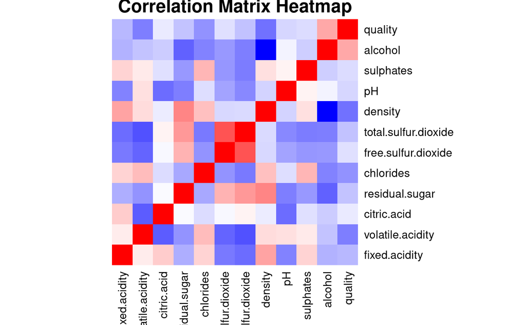

```r
# Select numeric columns
numeric_cols <- wine_df[, sapply(wine_df, is.numeric)]

# Compute correlation matrix
cor_matrix <- cor(numeric_cols, use = "complete.obs")

#plotting heatmap
heatmap(cor_matrix, Rowv = NA, Colv = NA, col = colorRampPalette(c("blue", "white", "red"))(256), scale = "none", main = "Correlation Matrix Heatmap")
```

Histogram chart for the numeric columns in the dataset

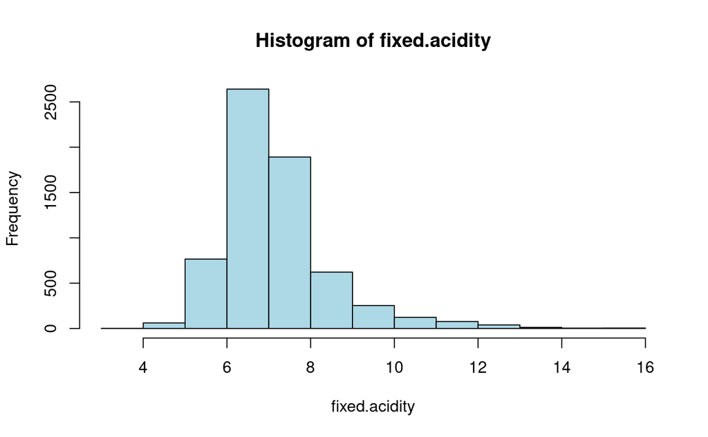

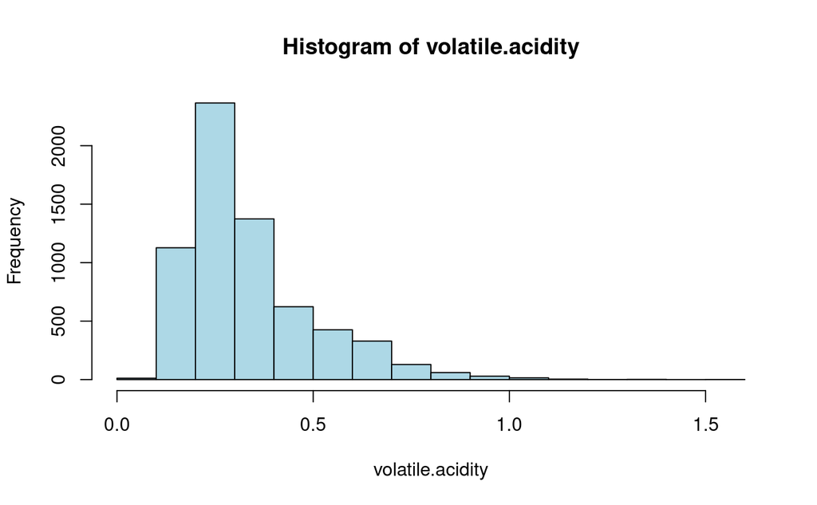

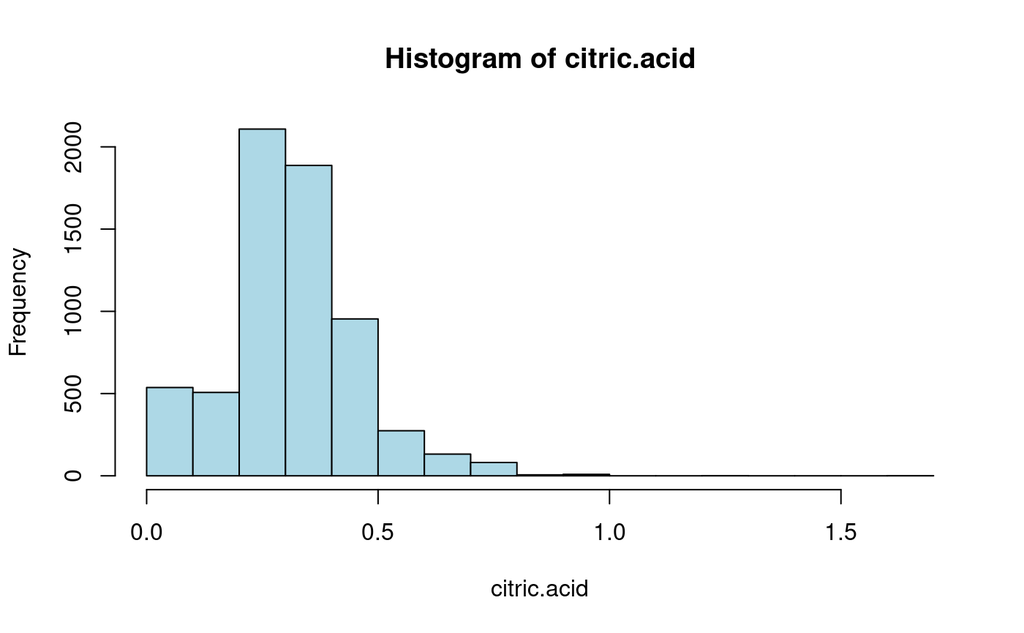

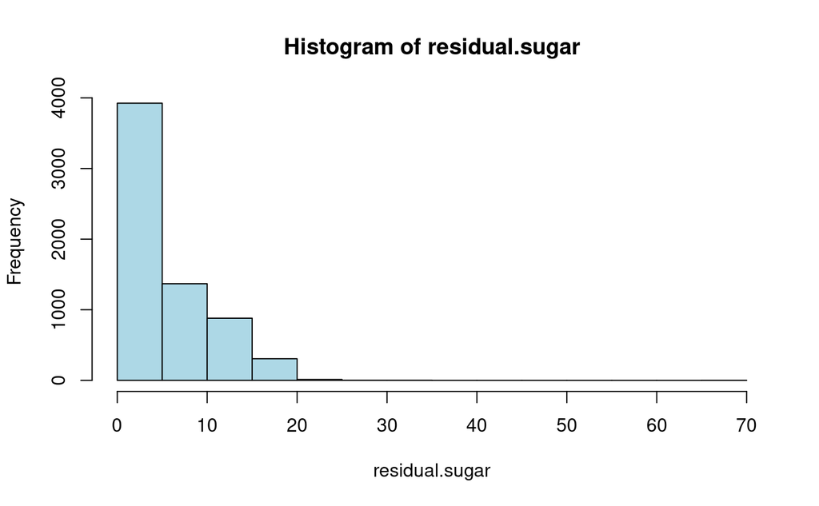

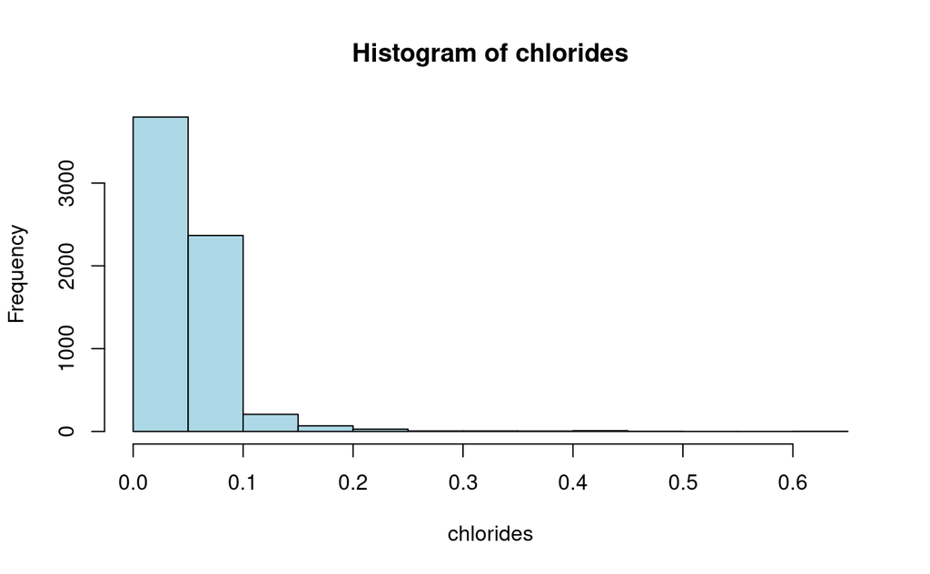

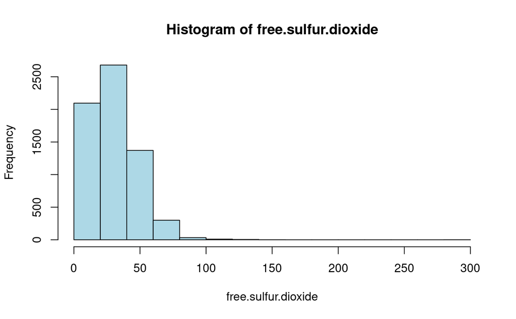

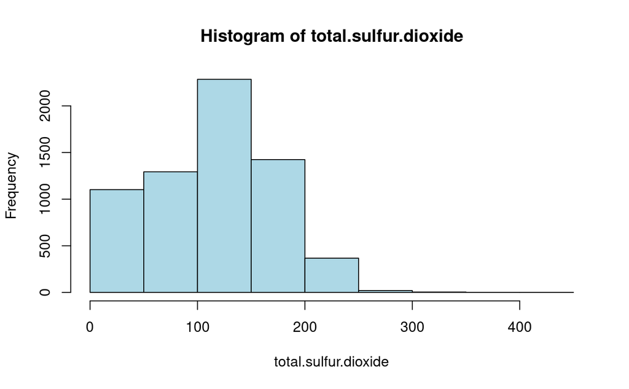

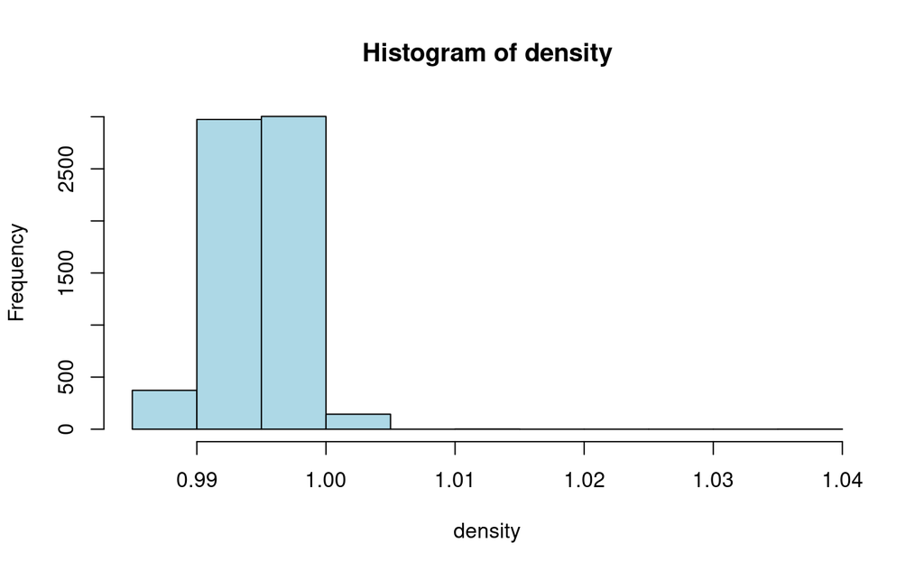

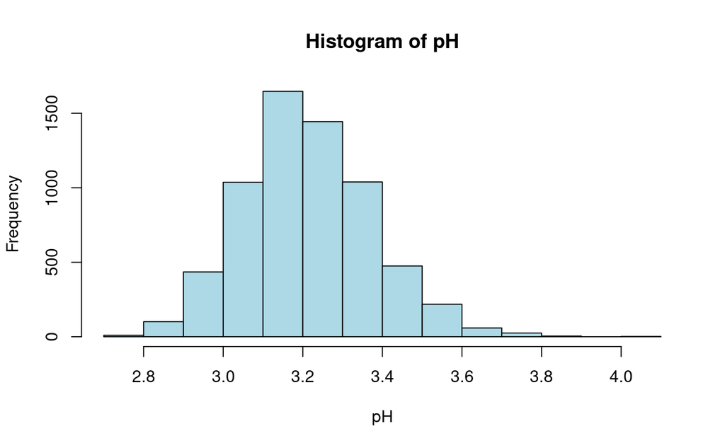

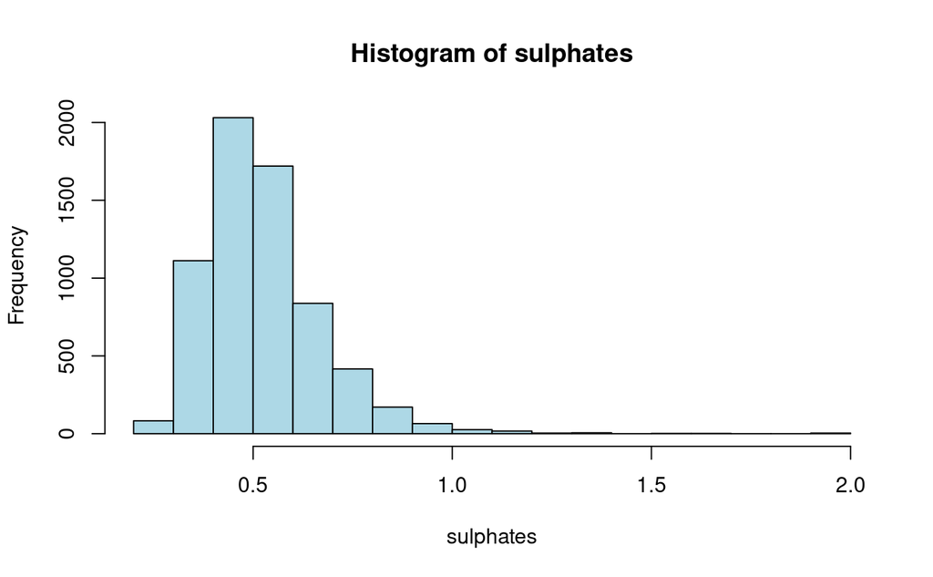

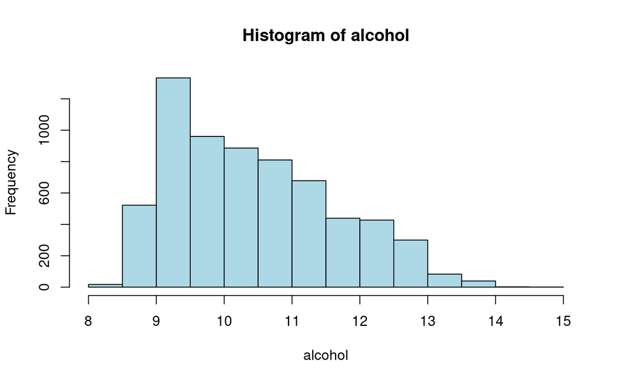

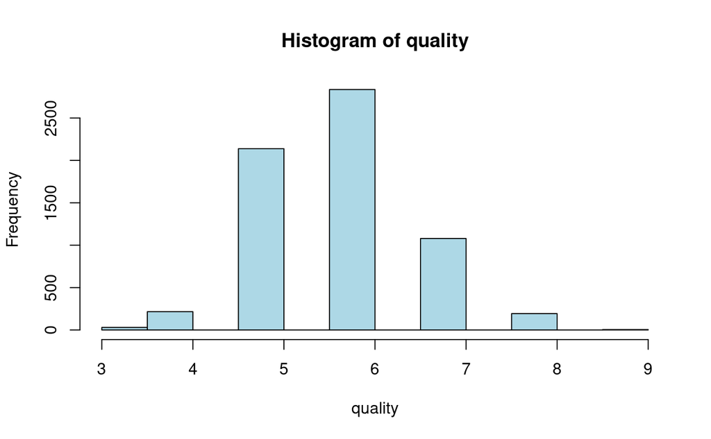

```r
for (col in names(wine_df)) {
  if (is.numeric(wine_df[[col]])) {
    hist(wine_df[[col]], main = paste("Histogram of", col), xlab = col, col = "lightblue", border = "black")
  }
}
```